# Title: Self-Supervised Domain Adaption on Sketchy (Sketch -> Photo) with Rotation Pretext

#### Group Member Names : Ngoc Quang Minh Nguyen, Ajju Dangol

#### Course: AIDI 1002

#### Date: 14/08/2025

### INTRODUCTION:

We investigate domain adaptation from labeled sketches to unlabeled photos using the Sketchy dataset. The significant distribution gap between sparse line drawings and real-world images motivates the use of self-supervised methods that do not rely on target labels. As an auxiliary pretext task, we apply rotation prediction (0°, 90°, 180°, 270°) to promote geometry-aware features that can be shared across domains. Our objective is to determine whether incorporating the rotation task enhances recognition performance on the photo domain compared to a baseline model without it.

#### AIM :

To evaluate the effectiveness of self-supervised domain adaptation from sketches to photos using the rotation prediction pretext task, and determine whether it improves recognition on the target photo domain without using photo labels.

#### Github Repo:

https://github.com/Jiaolong/self-supervised-da

#### DESCRIPTION OF PAPER:

The paper Self-Supervised Domain Adaptation for Computer Vision Tasks (arXiv:1907.10915) proposes combining supervised learning on a labeled source domain with a self-supervised pretext task on both source and target domains. Specifically, the method uses rotation prediction (0°, 90°, 180°, 270°) as the auxiliary task to encourage learning geometry-aware features that are transferable across domains. This approach improves performance on the target domain without requiring any target labels.

#### PROBLEM STATEMENT :

Deep learning models trained on one domain often perform poorly on another due to domain shift. In our case, sketches and real photos have large differences in texture, color, and detail. We aim to bridge this gap so a model trained with only labeled sketches can recognize objects in unlabeled photos.

#### CONTEXT OF THE PROBLEM:

- The Sketchy dataset contains two domains — sketches and photos — representing the same object classes but with very different visual styles.
- Traditional supervised learning cannot be applied directly to the target (photo) domain due to the lack of labels.
- Domain adaptation is needed to align the feature distributions of sketches and photos.

#### SOLUTION:

# Background

[output not shown]

# Implement paper code :

## Repository:

- Paper: Self‑Supervised Domain Adaptation for Computer Vision Tasks (arXiv:1907.10915)
- Codebase: Jiaolong/self-supervised-da (PyTorch)

## Environment (Conda):

```
conda env update -f environment.yml
```

## Parameters change in repo:

- config/*.yaml → dataset paths, source/target domains, epochs, batch size, LR, rotation settings.
- main.py → reads YAML; (we added optional MPS detection).
- models/aux_model.py → loss composition (classification + λ·rotation), optimizer/scheduler.
- data/data_loader.py → DataLoader settings, image transforms, domain names.

## Baseline on PACS (5 epochs)

```
python main.py --config config/rotate_pacs_photo.yaml
```

## Output:

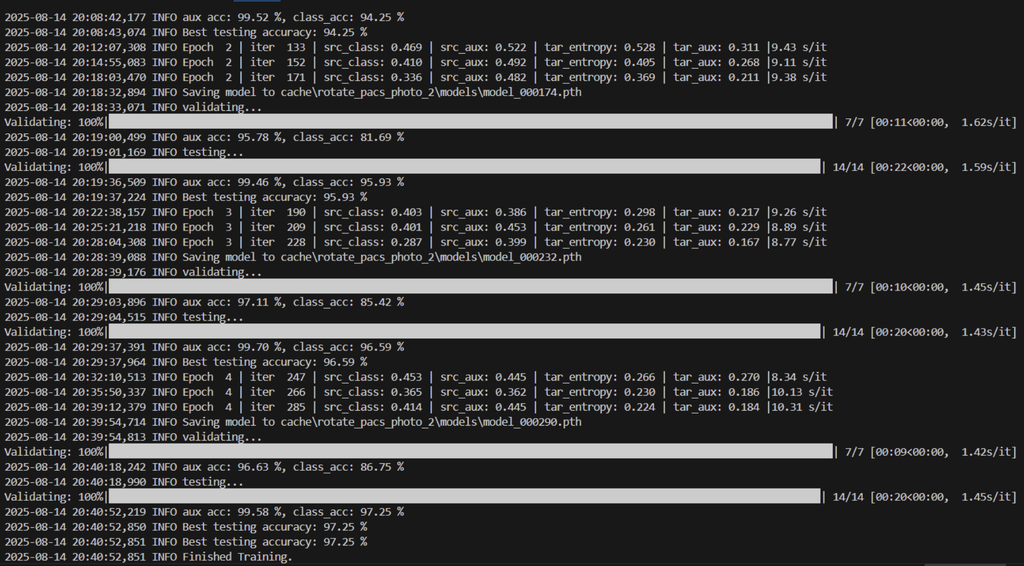

## Interpretation:

- Target accuracy rose to 97%.25%, target entropy fell 1.78 -> 0.22, aux acc = 99-100%

### Contribution Code :

**Goal:** Apply the paper's method to a new dataset (Sketchy), training on sketches (labeled) and adapting to photos (unlabeled). We will used 10 shared classes.

**Data Folder:** datasets/sketchy/sketch/<10 class folders>/ datasets/sketchy/photo/<10 class folders>/

**Training config (sketch->photo)**

```
DATA:
  ROOT: datasets
  NAME: SKETCHY
  PATH: datasets/sketchy
  SOURCE: sketch
  TARGET: photo

MODEL:
  ARCH: resnet50

SOLVER:
  EPOCHS: 20
  BATCH_SIZE: 16         # drop to 8 if memory issues
  LR: 0.00015
  NUM_WORKERS: 2

SCHEDULER:
  TYPE: step
  STEP_SIZE: 10          # with 20 epochs, decay once mid-training
  GAMMA: 0.1

PRETEXT:
  USE_ROTATION: true
  ROT_WEIGHT: 0.5
  ANGLES: [0, 90, 180, 270]

OUTPUT:
  DIR: outputs/sketch2photo_rot_10cls
  DEVICE: auto          # cuda/mps/cpu
```

**Running**

```
python3 main.py --config config/rotate_sketchy_to_photo.yaml
```

**What to monitor (logs)**

- src_class ↓ : supervised loss on sketches (should drop)
- tar_aux ↓ : rotation loss on photos (aux task learning)
- tar_entropy ↓ : confidence on photos (good adaptation)
- Best testing accuracy on photo test set

### Results :

- With 20 epochs / 10 classes, best target (photo) accuracy was ~47% in one direction (and ~96% on source), showing partial transfer but a large gap vs. PACS → due to the much harder sketch↔photo shift and the small subset.
- Rot pretext reached ~100% aux accuracy quickly; consider more epochs, more classes, or stronger SSL (e.g., contrastive) if time allows.

#### Observations :

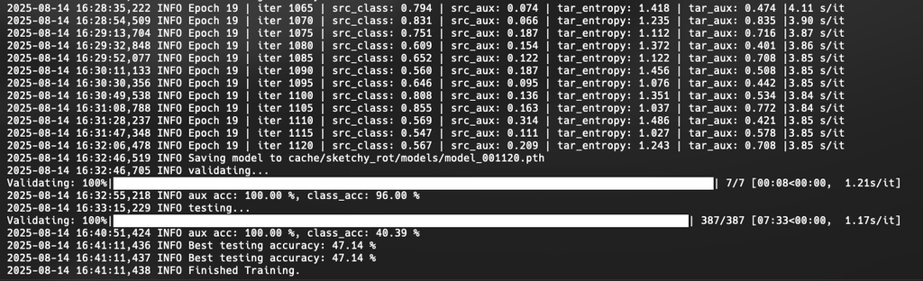

### Conclusion and Future Direction :

#### Learnings :

- Self-supervised rotation pretext can be integrated easily into an existing domain adaptation framework.
- Adapting from sketches to photos is challenging due to large visual style differences.
- Reducing the dataset to 10 classes speeds up training significantly but may reduce adaptation effectiveness.

#### Limitations :

- Small class subset and short training time limit generalizability of results.
- Rotation alone may not be enough to align sketches with realistic photos.
- Training on MPS (Mac GPU) is slower than CUDA and may require smaller batch sizes, which can affect convergence.

#### Future Extension :

- Test on the full 126-class Sketchy dataset for more realistic evaluation.
- Explore additional pretext tasks (contrastive learning, jigsaw puzzles) alongside rotation.
- Incorporate adversarial domain alignment to complement self-supervised learning.
- Experiment with different backbones (e.g., Vision Transformers) for richer feature representations.

# References:

[1]: Self‑Supervised Domain Adaptation for Computer Vision (arXiv:1907.10915). [2]: Sketchy Database (Rendered sketches & augmented photos). [3]: https://github.com/minhnguyen051201/Final_Project_MLP